# Tuto_package

Amélie Picard and Baptiste Lanoue

07/12/2020

This vignette gives a high level overview on how to use the clustyanaly R package

```r
library(clustyanaly)
```

## Use clustyanaly index

We will show you how we can use internal index from the package

```r
data("iris")
df <- iris
head(df, 3)
```

|  | Sepal.Length | Sepal.Width | Petal.Length | Petal.Width | Species |
| --- | --- | --- | --- | --- | --- |
| 1 | 5.1 | 3.5 | 1.4 | 0.2 | setosa |
| 2 | 4.9 | 3.0 | 1.4 | 0.2 | setosa |
| 3 | 4.7 | 3.2 | 1.3 | 0.2 | setosa |

We will use iris data and we predict a kmean with cluster = 5 parameter must be a data frame and vector

```r
fit <- kmeans(scale(df[, -5]), 5)
clust <- fit$cluster
clust <- as.vector(clust)
df <- as.data.frame(scale(df[, -5]))
```

## Silhouette index

You can evaluate the silhouette index for each point of the data frame, cluster and general Value are beetween -1 and 1

```r
silhouette(df,clust)
```

```
## $s_coeff
## [1] 0.3318643
##
## $vect_point
##           1           2           3           4           5           6
##  0.72405221  0.52347088  0.66233475  0.58940397  0.71679840  0.56595855
##           7           8           9          10          11          12
##  0.69325430  0.72376191  0.41014899  0.60595389  0.64761296  0.71609300
##          13          14          15          16          17          18
##  0.53274854  0.49469332  0.50170429  0.39002113  0.58257155  0.71706873
##          19          20          21          22          23          24
##  0.53471960  0.65315054  0.63858588  0.66783714  0.68766918  0.61952970
##          25          26          27          28          29          30
##  0.69306747  0.50011116  0.69292577  0.70823741  0.70369218  0.65298228
##          31          32          33          34          35          36
##  0.59874809  0.62232468  0.55199780  0.49079073  0.60339918  0.66543661
##          37          38          39          40          41          43
##  0.64194533  0.71429836  0.49869527  0.71582003  0.72382441  0.61438207
##          44          45          46          47          48          49
##  0.64128861  0.61604792  0.51190397  0.65540888  0.64875673  0.66618809
##          50          42          54          58          60          61
##  0.70558808  0.12929454  0.49042602  0.46998194  0.17597648  0.46248930
##          63          68          69          70          80          81
##  0.38406419  0.02235194  0.08459701  0.44700332  0.30944086  0.52015966
##          82          83          88          90          91          93
##  0.51504839 -0.02375966  0.08828664  0.42617625  0.27651652  0.20721754
##          94          95          99         107         120          51
##  0.50002201  0.01036764  0.43906259  0.25939019  0.08003900 -0.08025549
##          53         101         103         105         106         108
## -0.09868111  0.22913879  0.30860950 -0.04321802  0.35951544  0.21541974
##         110         111         113         116         118         119
##  0.40715012  0.07860520  0.12436858  0.15250312  0.36507816  0.15039712
##         121         123         125         126         130         131
##  0.41000505  0.24633059  0.34855387  0.36398927  0.16743386  0.17344442
##         132         136         137         140         141         142
##  0.35063484  0.36392308  0.24657297  0.29389637  0.27588937  0.28945636
##         144         145         146         149          52          56
##  0.38893865  0.37271601  0.08562595  0.15483734  0.32736447  0.29177592
##          57          59          62          64          65          66
##  0.29539693  0.13586808  0.44338925  0.30712621  0.27193796  0.23013801
##          67          71          72          74          75          76
##  0.38958443  0.26663273  0.30755174  0.23729633  0.28173368  0.22438817
##          79          85          86          87          89          92
##  0.33072987  0.33641424  0.32446044  0.15539752  0.44544733  0.40993125
##          96          97          98         100         128         139
##  0.45863872  0.42646839  0.36896848  0.24320793  0.06988531  0.14143780
##         150          55          73          77          78          84
##  0.08279028  0.02394903  0.26128964  0.06380646  0.05712640  0.20135465
##         102         104         109         112         114         115
##  0.27678525  0.28100057  0.36754157  0.43678256  0.25827461  0.24653608
##         117         122         124         127         129         133
##  0.18516655  0.10604394  0.36434037  0.23142589  0.40878721  0.35758317
##         134         135         138         143         147         148
##  0.11277793  0.22349030  0.03598940  0.27678525  0.39110823  0.18804189
##
## $vect_clust
##         3         2         4         5         1
## 0.6211634 0.2851887 0.2310648 0.2890356 0.2328690
```

You can also choose a distance

```r
silhouette(df,clust,"manhattan")
```

```
## $s_coeff
## [1] 0.3485377
##
## $vect_point
##            1            2            3            4            5            6
##  0.796312783  0.662165440  0.733684016  0.688775711  0.795476625  0.644557947
##            7            8            9           10           11           12
##  0.758716088  0.796265176  0.558067377  0.695874755  0.730953086  0.783299978
##           13           14           15           16           17           18
##  0.647377610  0.584456069  0.586743633  0.500575590  0.663424618  0.782114237
##           19           20           21           22           23           24
##  0.607891218  0.751546427  0.716411851  0.745400096  0.751375225  0.674146388
##           25           26           27           28           29           30
##  0.749745722  0.648755403  0.752690846  0.780761066  0.777467775  0.727892209
##           31           32           33           34           35           36
##  0.697796522  0.693695212  0.683034472  0.622182277  0.709562880  0.740115173
##           37           38           39           40           41           43
##  0.718055949  0.781050676  0.617354486  0.790587065  0.783470955  0.699217497
##           44           45           46           47           48           49
##  0.698415227  0.691229149  0.639276128  0.758480468  0.727614550  0.749036701
##           50           42           54           58           60           61
##  0.777015348 -0.196298184  0.461093476  0.513849186  0.148579424  0.480495586
##           63           68           69           70           80           81
##  0.377912268  0.072464625  0.002522565  0.438058852  0.344432813  0.513772623
##           82           83           88           90           91           93
##  0.523704102  0.020289923  0.098182102  0.381486860  0.224391181  0.190330489
##           94           95           99          107          120           51
##  0.533232488 -0.051580905  0.469539759  0.188853501 -0.072328518 -0.213741736
##           53          101          103          105          106          108
## -0.204156803  0.225792812  0.336672545  0.030033512  0.376789658  0.145729739
##          110          111          113          116          118          119
##  0.450230703 -0.055268851  0.129513119  0.103171867  0.410470026  0.167176242
##          121          123          125          126          130          131
##  0.442027054  0.170741434  0.328226901  0.363261581  0.147392675  0.070474703
##          132          136          137          140          141          142
##  0.366606494  0.417431355  0.177087005  0.276865567  0.282619374  0.278097801
##          144          145          146          149           52           56
##  0.430104559  0.366927440  0.078461575  0.105729685  0.327311331  0.349374240
##           57           59           62           64           65           66
##  0.222663396  0.263592499  0.498459726  0.366192617  0.246039533  0.329123516
##           67           71           72           74           75           76
##  0.462914162  0.181752299  0.338950938  0.237914400  0.357120914  0.348382328
##           79           85           86           87           89           92
##  0.405130132  0.420471628  0.338664180  0.217840942  0.443692843  0.473643541
##           96           97           98          100          128          139
##  0.455043508  0.439243727  0.431672247  0.251046273  0.016452566  0.119725076
##          150           55           73           77           78           84
## -0.012272492 -0.058301696  0.227556030 -0.020517375  0.041285067  0.202809070
##          102          104          109          112          114          115
##  0.333736156  0.312867269  0.344924424  0.506274943  0.296448068  0.246569072
##          117          122          124          127          129          133
##  0.226733134  0.160984128  0.407979055  0.242741983  0.383937797  0.330178390
##          134          135          138          143          147          148
##  0.168758118  0.186408128  0.161897922  0.333736156  0.447666284  0.215832371
##
## $vect_clust
##         3         2         4         5         1
## 0.7075534 0.2574084 0.2139472 0.3159313 0.2478480
```

## Davies bouldin index

You can evaluate the Davies_bouldin index the lower the value, the better is the clustering

```r
davies_bouldin(df,clust)
```

```
## $davies_bouldin
## [1] 1.054275
```

You can also choose a distance

```r
davies_bouldin(df,clust,"maximum")
```

```
## $davies_bouldin
## [1] 1.382659
```

## Dunn index

You can evaluate the Dunn index the higher the value, the better is the clustering You have different evaluation of Dunn in function of the distance beetwenn cluster(mean,max,min)

```r
dunn(df,clust)
```

```
## $dunn_mean
## [1] 0.2272912
##
## $dunn_min
## [1] 0.06998386
##
## $dunn_max
## [1] 0.3758038
```

You can also choose a distance

```r
dunn(df,clust,"canberra")
```

```
## $dunn_mean
## [1] 0.4719319
##
## $dunn_min
## [1] 0.05400022
##
## $dunn_max
## [1] 0.4593157
```

## Variance index

You can evaluate different variance index like calinski_harabasz coefficient, Ball_hall coefficient, Hartigan coefficient and Xu coefficient.

```r
variance_index(df,clust)
```

```
## $calinski_harabasz
## [1] 170.6487
##
## $ball_hall
## [1] 0.6679427
##
## $Hartigan
## [1] 1.549168
##
## $Xu
## [1] -18.79392
```

## Example with Davies Bouldin index

We can find the best number cluster for our model with Davies Bouldin index for example

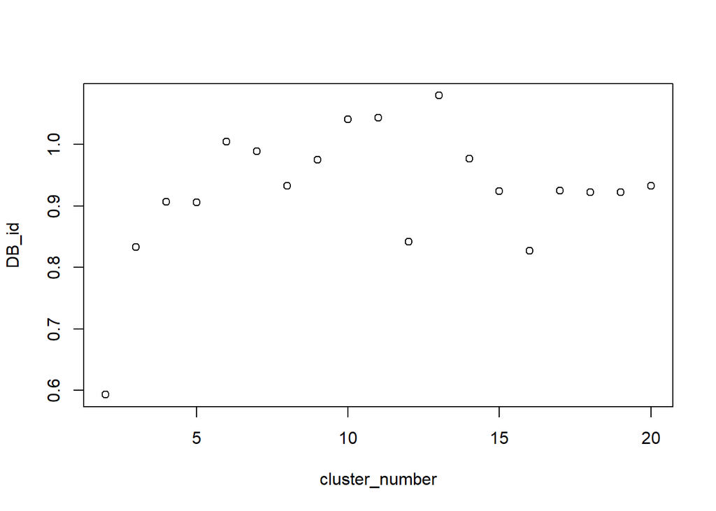

```r
fit <- kmeans(scale(df[, -5]), 5)
clust <- fit$cluster
clust <- as.vector(clust)
df <- as.data.frame(scale(df[, -5]))
DB_id <- c()
for (k in 2:20){
  fit <- kmeans(scale(df[, -5]), k)
  clust <- fit$cluster
  clust <- as.vector(clust)
  DB_id <- append(DB_id ,davies_bouldin(df,clust))
}
cluster_number <- c(2:20)
plot(cluster_number,DB_id)
```

## Tutorial for univariate and multivariate characterization

We are going to graphically represent three datasets. We take for this tutorial a data frame with quantitative variable “mtcars”, a data frame with qualitative variable “canine” and finally a data frame with both type of data “small_apb”.

Load data :

The data frame “canines” and “small_apb” have already a column with the class value of individuals. It’s the last column of the data frame.

Load the canines data :

```r
#group variable :
groupe_canines<-canines[8]
#analysis variables
df_canines<-canines[c(-1,-8)]
rownames(df_canines)<-canines[,1]
```

Load the small_apb data :

```r
#group variable :
apb_groupe<-small_apb[,length(small_apb)]
#analysis variables
apb<-small_apb[c(-1,-length(small_apb))]
```

The data frame “mtcars” does not have columns representing groups of individuals. We are therefore going to make a hierarchical ascending classification (hac) to create groups.

Load the mtcars data:

```r
#center and reduce data
mtcars.cr <- scale(mtcars,center=T,scale=T)
#calculating of distance
d.mtcars <- dist(mtcars.cr)
#hierarchical ascending classification with method ward
cah.ward2 <- hclust(d.mtcars,method="ward.D2")

#group variable with 4 class:
groupes.cah2 <- cutree(cah.ward2,k=4)
#analysis variables : mtcars
```

## Creation of type ‘ClusteringData’ :

Thanks to the function “data_manager()”, we can create an object of class ‘ClusteringData’. This object allows you to simply use the other functions accessible from the package.

```r
#for canine data
canine_objet<-data_manager(df_canines,groupe_canines)
#for mtcars data
cars<-data_manager(mtcars,groupes.cah2)
#for small_apb data
apb_objet<-data_manager(apb,apb_groupe)
```

## Display data graphs univariate

Display data graphs univariate by data type (quantitative or qualitative variables). If the data has both types of data, all graphs are displayed, else only the corresponding graphs are displayed.

For qualitative data :

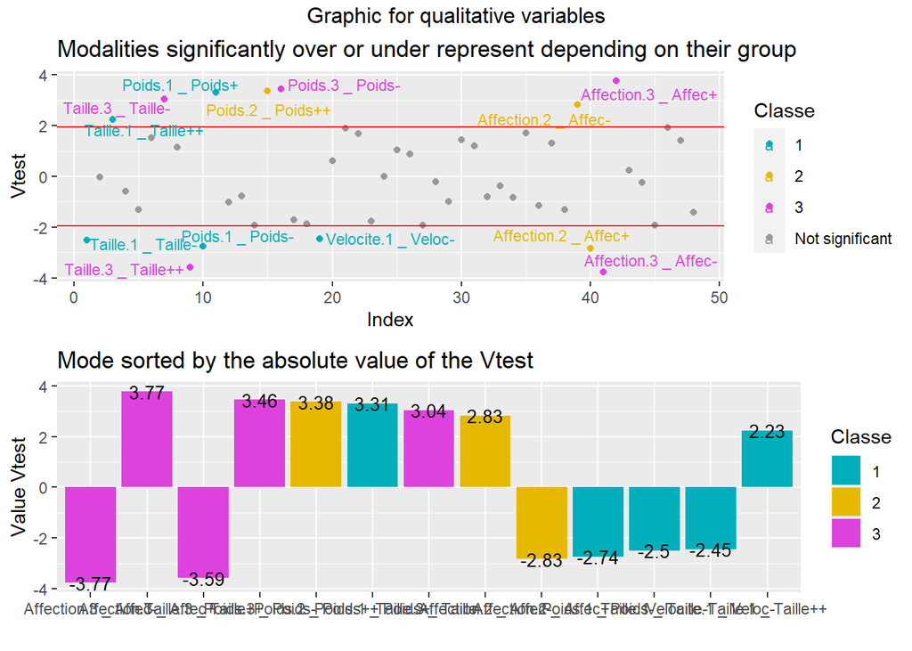

```
## [1] "Table for variable : "
## [1] "Taille"
## [1] "Contingency table"
## Margins computed over dimensions
## in the following order:
## 1: groupe
## 2:
##
## groupe  Taille- Taille+ Taille++ Total
##   1           0       2        9    11
##   2           1       0        5     6
##   3           6       3        1    10
##   Total       7       5       15    27
## [1] "Row profiles table"
##
## groupe  Taille- Taille+ Taille++  Total
##   1        0.00   18.18    81.82 100.00
##   2       16.67    0.00    83.33 100.00
##   3       60.00   30.00    10.00 100.00
##   Total   25.93   18.52    55.56 100.01
## [1] "Column profiles table"
##
## groupe  Taille- Taille+ Taille++  Total
##   1        0.00   40.00    60.00  40.74
##   2       14.29    0.00    33.33  22.22
##   3       85.71   60.00     6.67  37.04
##   Total  100.00  100.00   100.00 100.00
## [1] "Table for variable : "
## [1] "Poids"
## [1] "Contingency table"
## Margins computed over dimensions
## in the following order:
## 1: groupe
## 2:
##
## groupe  Poids- Poids+ Poids++ Total
##   1          0     10       1    11
##   2          1      1       4     6
##   3          7      3       0    10
##   Total      8     14       5    27
```

[output cut: 269 more lines]

```
##   Total      14      13    27
## [1] "Row profiles table"
##
## groupe  Agress- Agress+  Total
##   1       54.55   45.45 100.00
##   2       16.67   83.33 100.00
##   3       70.00   30.00 100.00
##   Total   51.85   48.15 100.00
## [1] "Column profiles table"
##
## groupe  Agress- Agress+  Total
##   1       42.86   38.46  40.74
##   2        7.14   38.46  22.22
##   3       50.00   23.08  37.04
##   Total  100.00  100.00 100.00
```

```r
#for canine data
get_graph_car_univ(canine_objet)
```

For quantitative data :

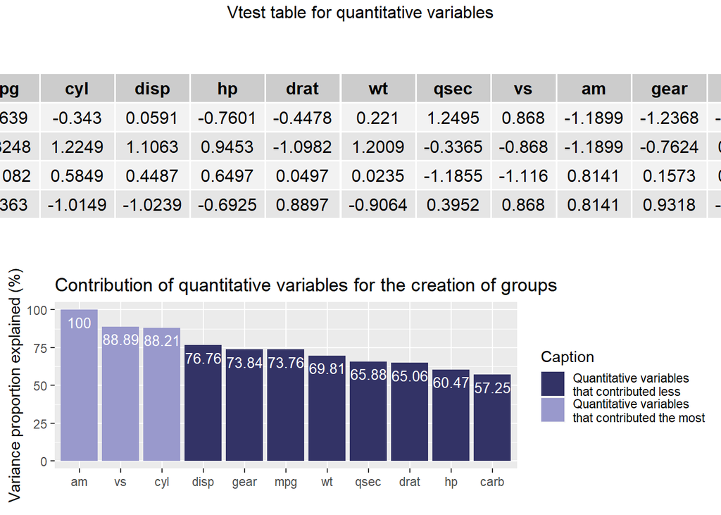

```r
#for mtcars data
get_graph_car_univ(cars)
```

For mixed data :

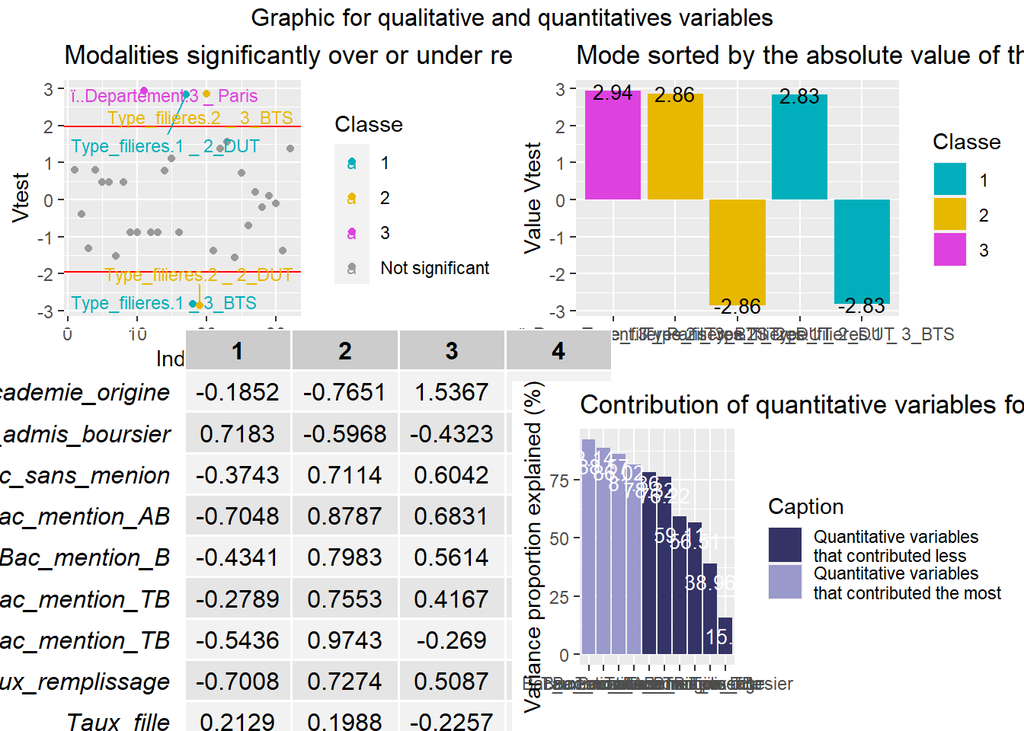

```
## [1] "Table for variable : "
## [1] "ï..Departement"
## [1] "Contingency table"
## Margins computed over dimensions
## in the following order:
## 1: groupe
## 2:
##
## groupe  Bouches-du-RhÃ´ne Gironde Paris Savoie Total
##   1                     2       1     0      2     5
##   2                     2       2     0      2     6
##   3                     0       0     2      0     2
##   4                     0       1     1      0     2
##   Total                 4       4     3      4    15
## [1] "Row profiles table"
##
## groupe  Bouches-du-RhÃ´ne Gironde  Paris Savoie  Total
##   1                 40.00   20.00   0.00  40.00 100.00
##   2                 33.33   33.33   0.00  33.33  99.99
##   3                  0.00    0.00 100.00   0.00 100.00
##   4                  0.00   50.00  50.00   0.00 100.00
##   Total             26.67   26.67  20.00  26.67 100.01
## [1] "Column profiles table"
##
## groupe  Bouches-du-RhÃ´ne Gironde  Paris Savoie  Total
##   1                 50.00   25.00   0.00  50.00  33.33
##   2                 50.00   50.00   0.00  50.00  40.00
##   3                  0.00    0.00  66.67   0.00  13.33
##   4                  0.00   25.00  33.33   0.00  13.33
##   Total            100.00  100.00 100.00 100.00  99.99
## [1] "Table for variable : "
## [1] "Type_filieres"
## [1] "Contingency table"
## Margins computed over dimensions
## in the following order:
## 1: groupe
## 2:
##
## groupe  2_DUT 3_BTS Total
##   1         5     0     5
```

[output cut: 125 more lines]

```
##
## groupe  Production Service  Total
##   1          60.00   40.00 100.00
##   2          50.00   50.00 100.00
##   3          50.00   50.00 100.00
##   4           0.00  100.00 100.00
##   Total      46.67   53.33 100.00
## [1] "Column profiles table"
##
## groupe  Production Service  Total
##   1          42.86   25.00  33.33
##   2          42.86   37.50  40.00
##   3          14.29   12.50  13.33
##   4           0.00   25.00  13.33
##   Total     100.01  100.00  99.99
```

```r
#For small_apb data
get_graph_car_univ(apb_objet)
```

For a better analysis of quantitative variables, it’s possible to display matching graphics

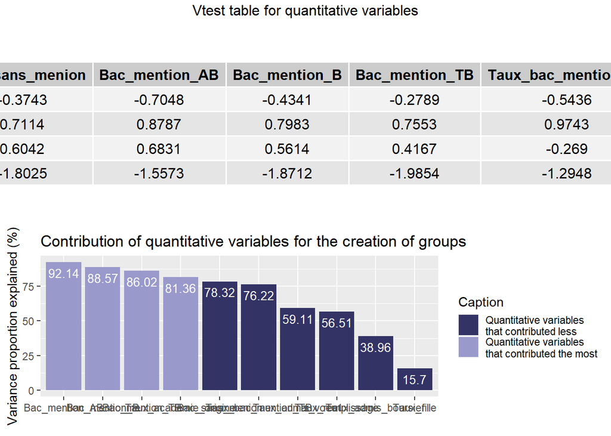

```r
#For small_apb data
get_graph_car_univ(apb_objet,choice_graph = "quanti")
```

## Display data graphs multivariate

Display data graphs multivariate according to factor analysis performed.

For qualitative data :

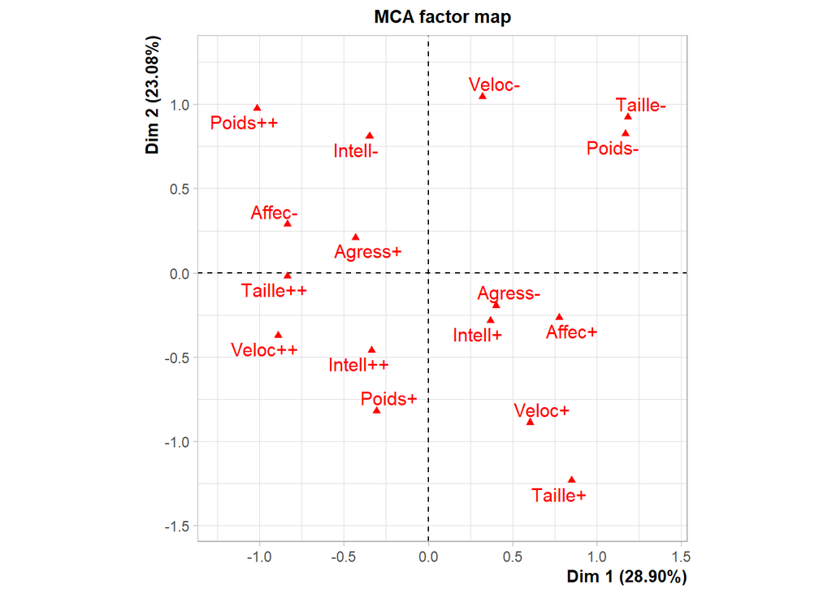

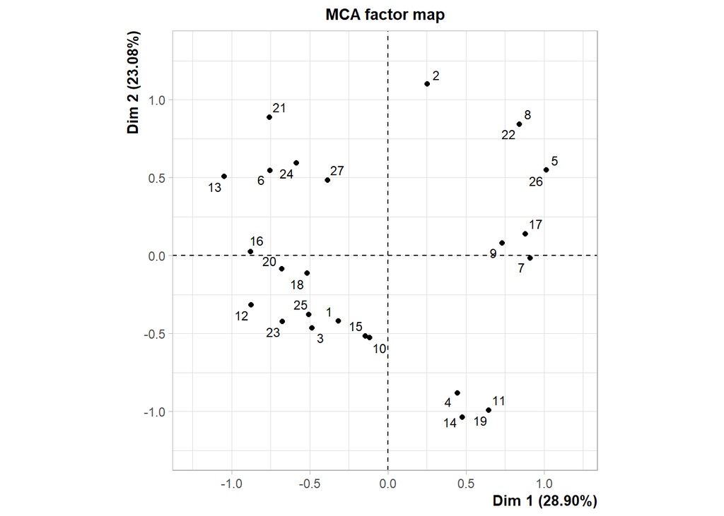

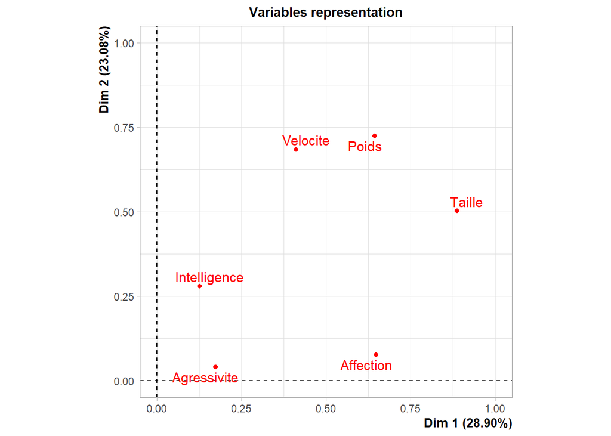

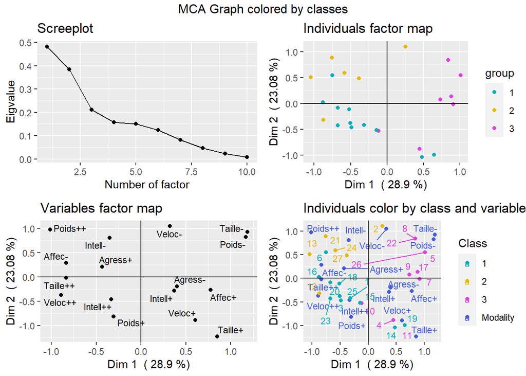

```r
mca_graph(canine_objet)
```

For quantitative data :

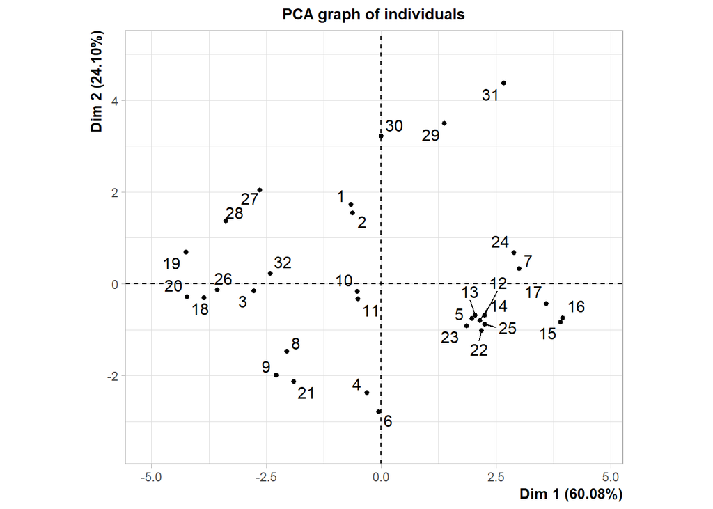

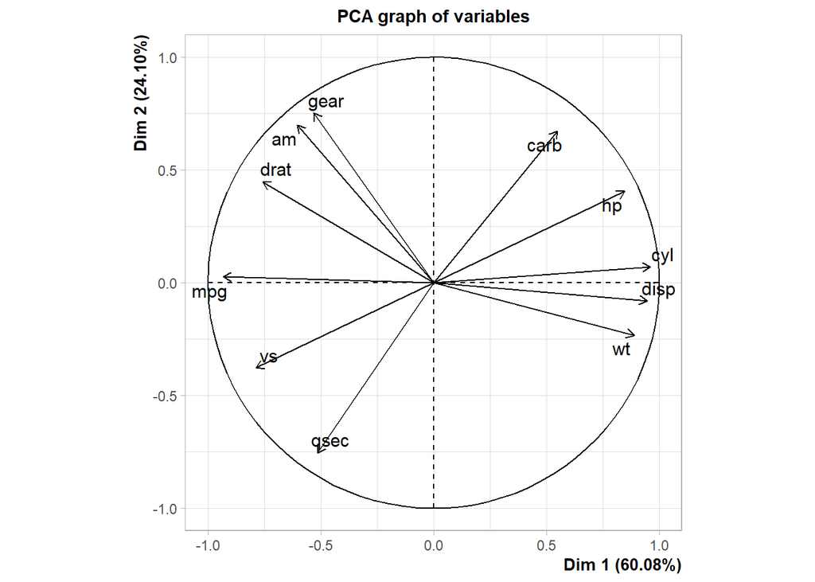

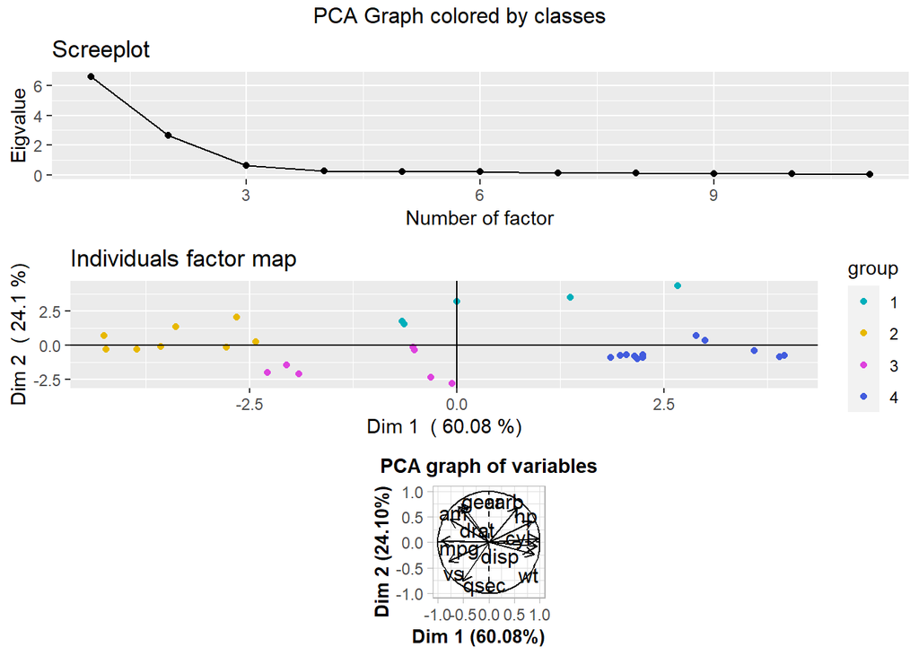

```r
pca_graph(cars)
```

For mixed data :

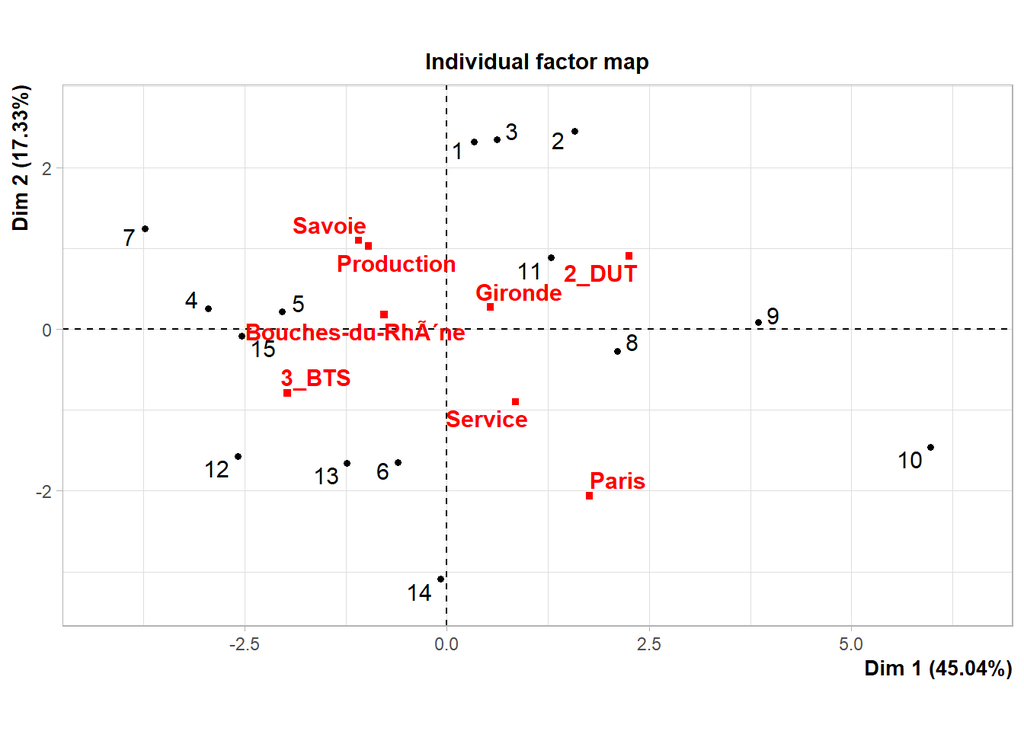

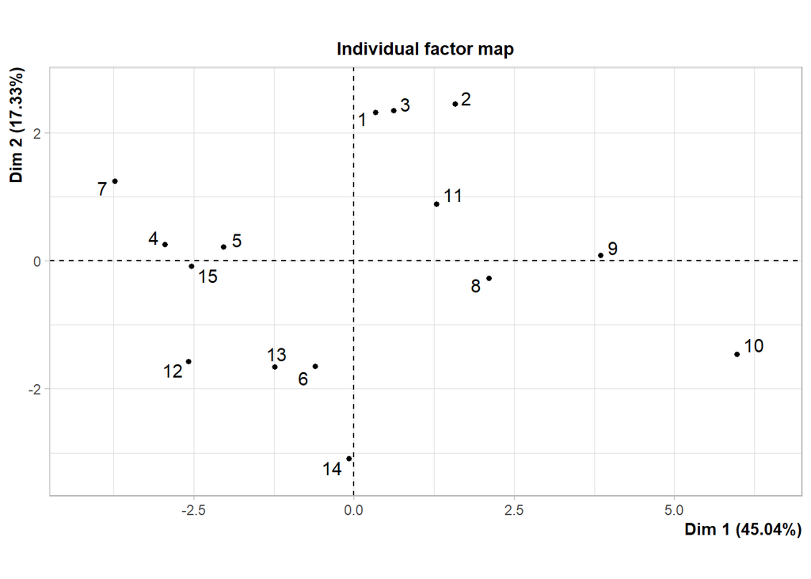

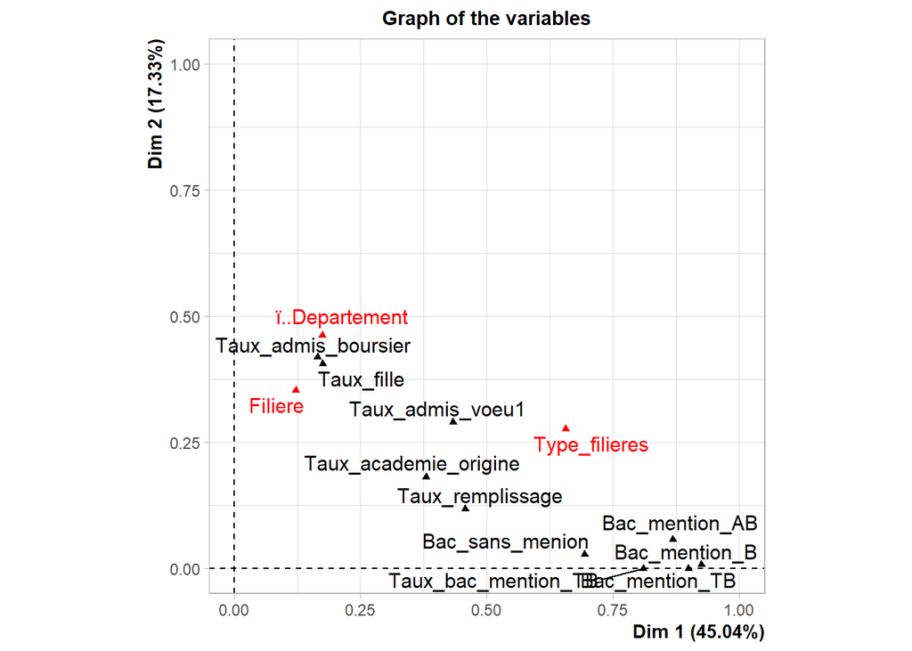

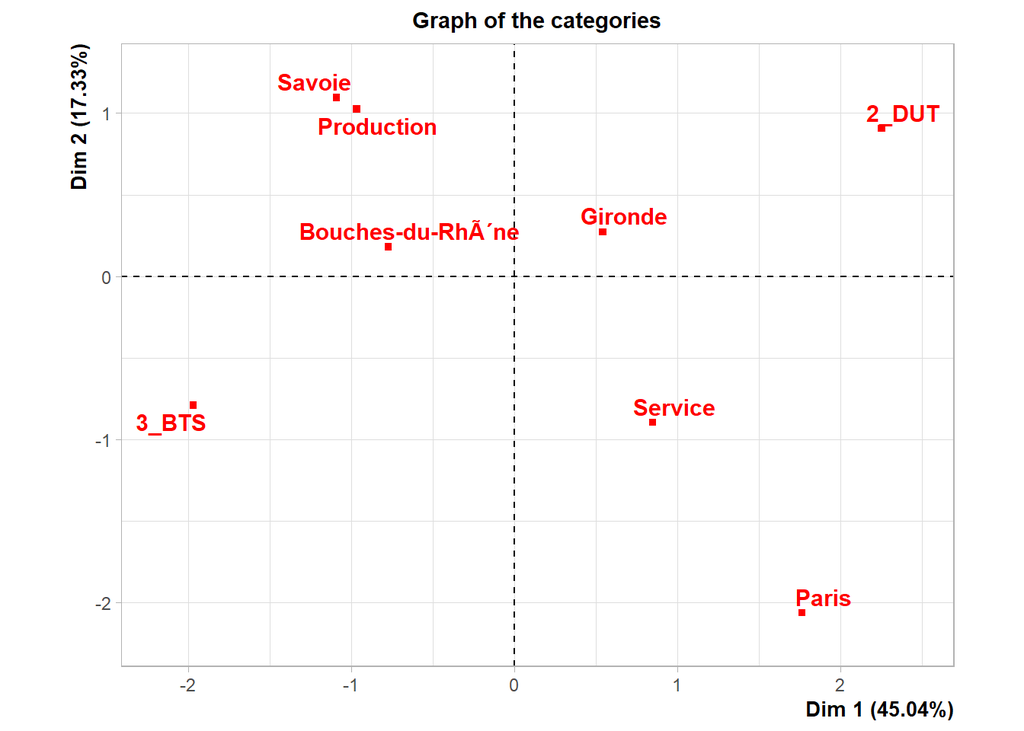

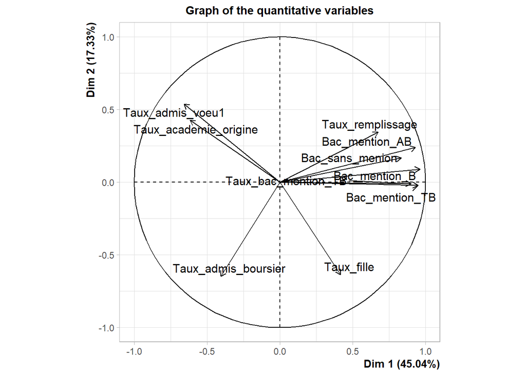

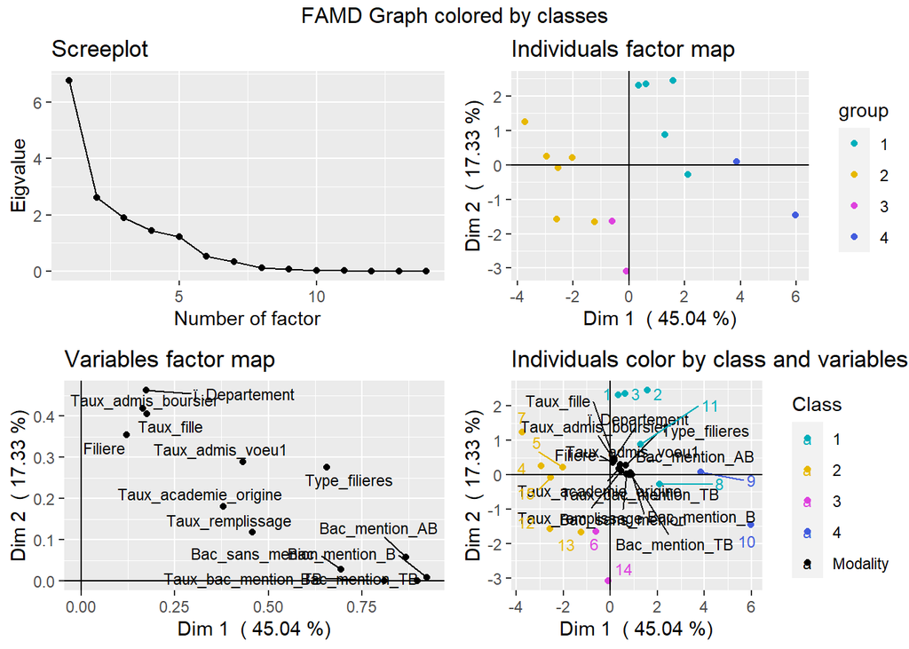

```r
famd_graph(apb_objet)
```

Some features are modifiable like, which graphic it is possible to display, and which dimension of factor analysis is to represent or the colors of the graphics. Note : that the color vector must have at least the same number of colors as the data has classes.

## Example :

We want to see the graphs, for mixed data, containing information on individuals. And for AFMD dimensions 1 and 3.

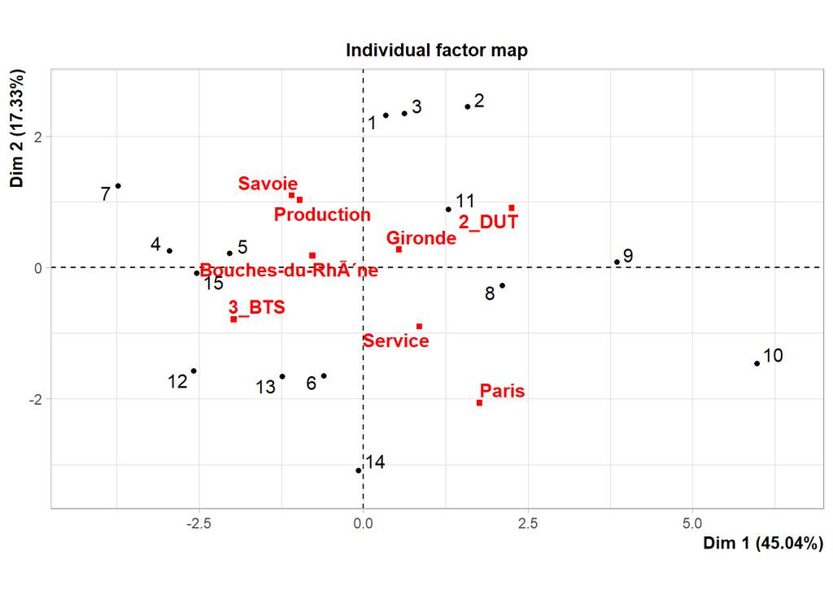

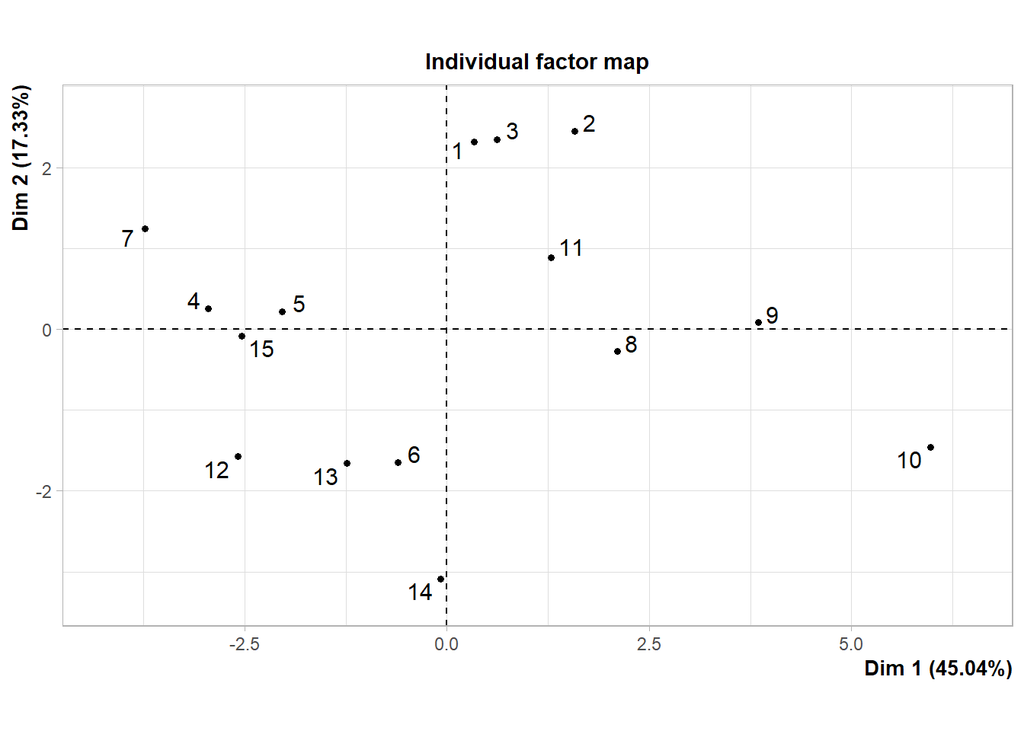

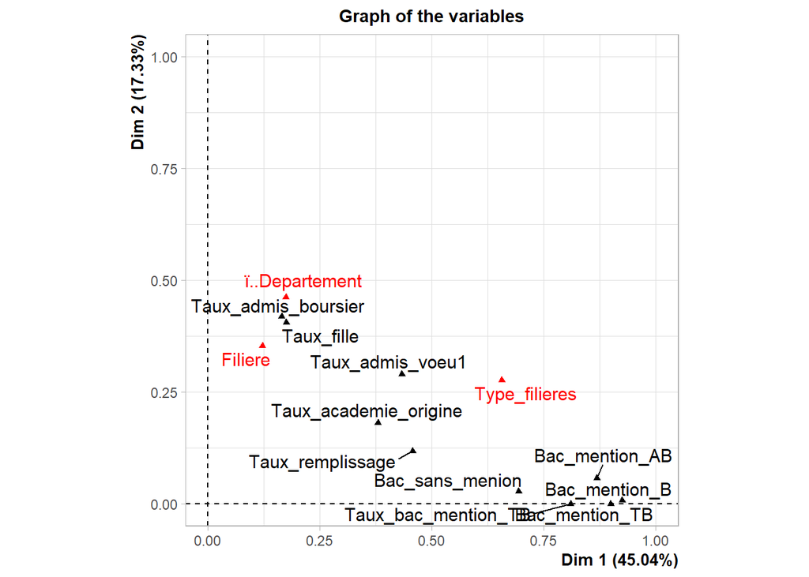

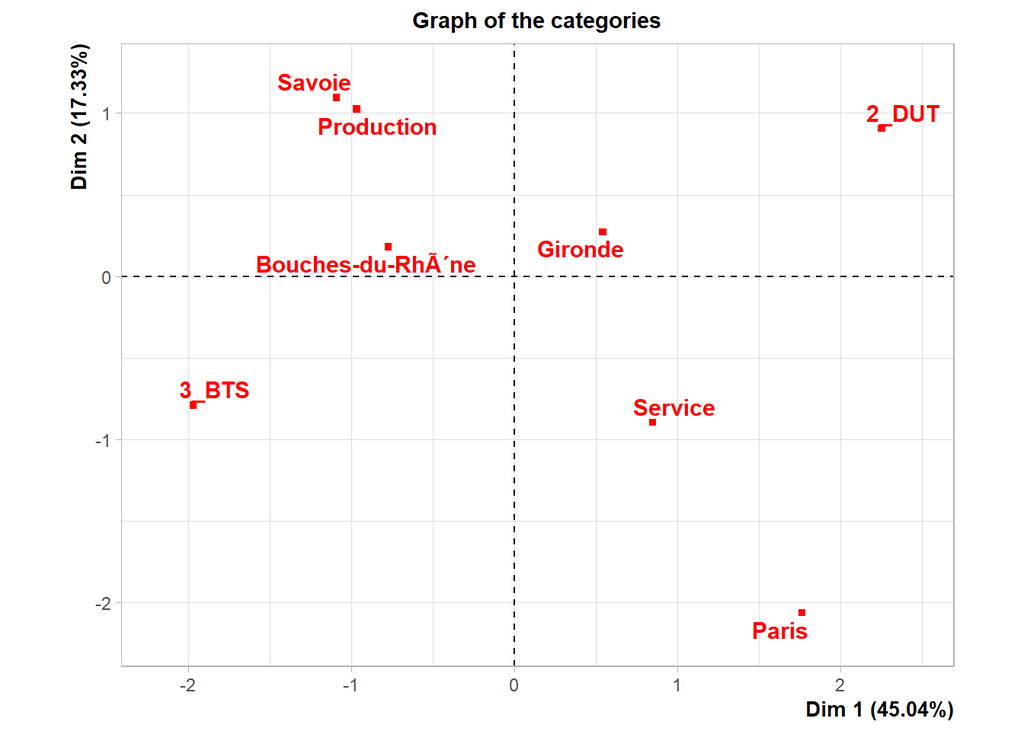

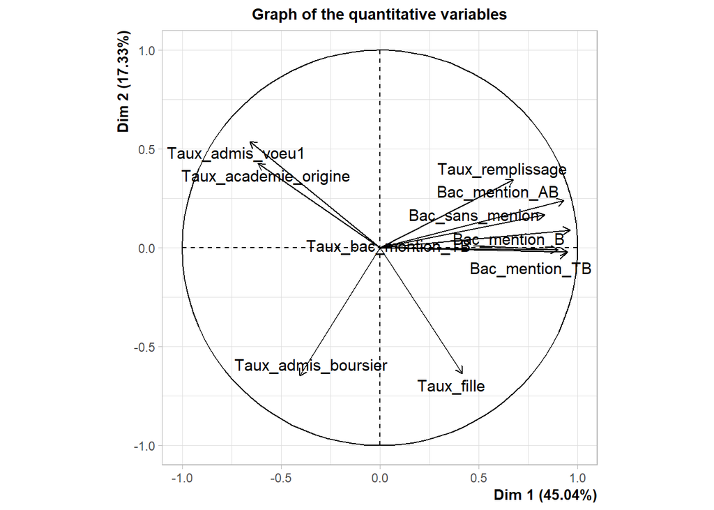

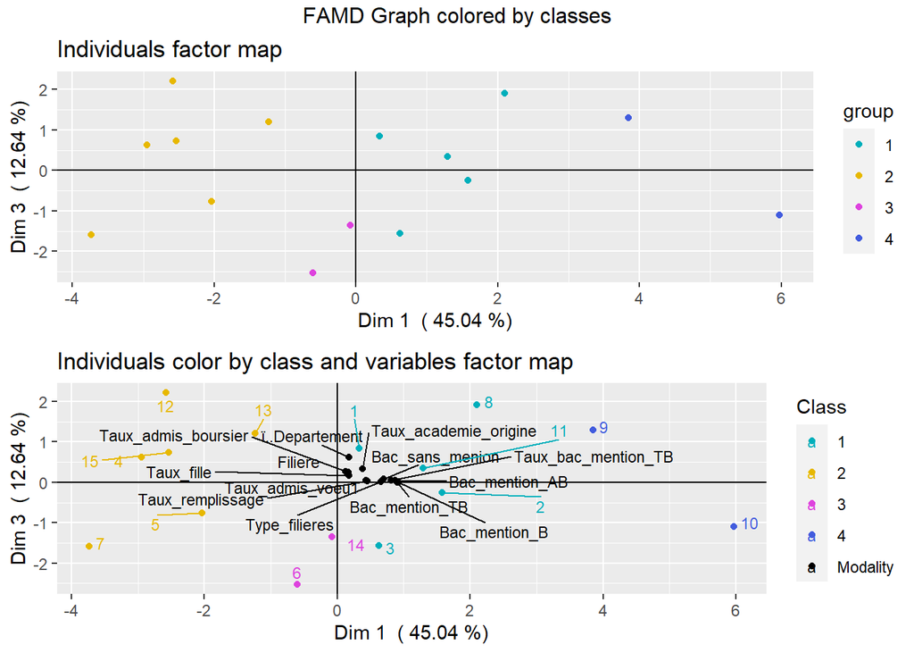

```r
famd_graph(apb_objet,axes = c(1,3),graph = c("ind","indpvar"))
```